# Nonparametric Estimation of the drift function

Eddy Ella Mintsa

27/04/2023

Consider the diffusion process $X=(X_t)_{t\in[0,1]}$, unique solution of the following stochastic differential equation

$$dX_t = b(X_t)dt + \sigma(X_t)dW_t ~~ ~~ ~~ ~~ (1)$$
where the drift function $b$ and the diffusion coefficient $\sigma$ are unknown Lipschitz functions, and there exists constants $\sigma_1>\sigma_0>0$ such that $\sigma(x) \in [\sigma_0,\sigma_1]$ for all $x\in\mathbb{R}$.

We will work in the sequel with the following diffusion models:

$$\begin{cases} \mathrm{Model} ~ 1: ~ b(x) = 1 - x, ~~ \sigma(x) = 1 ~~ ~~ ~~ ~~ (\mathrm{Ornstein-Uhlenbeck}) \\ \\
\mathrm{Model} ~ 2: b(x) = -2x/\sqrt{1+x^2}, ~~ \sigma(x) = 1
\end{cases}$$

To use these diffusion models in practice, we record them using the function $\texttt{coef.fun}$ implemented below

```r
coef.fun<-function(fun.name){
   if(fun.name=="drift.model1") out<-function(x) 1 - x;
   if(fun.name=="drift.model2") out<-function(x) -2*x/sqrt(1+x**2)

   if(fun.name=="sig.model1") out<-function(x) sapply(x,function(a) 1);               # Diffusion coefficient
   if(fun.name=="sigx.model1") out<-function(x) 0;                                    # Its derivative

   if(fun.name=="drift") out<-function(x) drift(x);
   if(fun.name=="sig") out<-function(x) sig(x);
   if(fun.name=="sig.x") out<-function(x) sig.x(x);
   if(fun.name=="sig.square") out<-function(x) sig(x)*sig(x)

   return(out)
}
```

The simulation and study of the process $X$ requires mainly the $\texttt{R}$-packages $\texttt{sde}$ (https://cran.r-project.org/web/packages/sde/sde.pdf) and $\texttt{fda}$ (https://cran.r-project.org/web/packages/fda/fda.pdf).

```r
library(MASS)
library(stats4)
library(Matrix)
library(fda)
library(sde)
library(rootSolve)
library(ggplot2)
library(cowplot)
library(data.table)
library(DepthProc)
library(tictoc)
```

We use the function $\texttt{sde.sim}$ of $\texttt{R}$-package $\texttt{sde}$ to simulation diffusion paths.

```r
model.sim<-function(x0,n,N,model){
  d<-expression(drift(x))
  s<-expression(sig(x)); s.x<-expression(sig.x(x))

  if(model=="model1") X=sde.sim(t0=0,T=1,X0=x0,N=n+1,M=N,theta=c(1,1,1),model="OU")
  if(model=="model2") X=sde.sim(t0=0,T=1,X0=x0,N=n+1,M=N,theta=c(1,1,1),model="CIR")
  if(model=="drift") X=sde.sim(t0=0,T=1,X0=x0,N=n+1,M=N,drift=d,sigma=s,sigma.x=s.x)

  return(X)
}
```

The function $\texttt{model.sim}$ takes as arguments the value $x_0$ of the diffusion process at $t=0$, the length $n$ of each diffusion path, the number $N$ of diffusion paths and the chosen model $\texttt{model}$ which is a vector containing the name of the drift diffusion or the diffusion coefficient. The function returns $N$ independent observations of the process $X$ at discret time with time-step $\Delta = 1/n$. We can choose as diffusion model, the Ornstein Uhlenbeck model (OU), the Cox Ingersoll Ross model (CIR), or any other model characterized by the drift and the diffusion coefficients including the OU model.

```r
#### Simulation of models 1, 2 and 3
N=100; n=100; delta = 1/n; x0=0

#### Model 1
drift <- coef.fun("drift.model1"); sig <- coef.fun("sig.model1"); sig.x <- coef.fun("sigx.model1")
model.name <- "drift"
S1 <- model.sim(x0,n,N,model.name)

#### Model 2
drift <- coef.fun("drift.model2"); sig <- coef.fun("sig.model1"); sig.x <- coef.fun("sigx.model1")
model.name <- "drift"
S2 <- model.sim(x0,n,N,model.name)
```

$\textbf{Estimation of the drift function on the real line} \ \mathbb{R}$

The drift function $b$ is estimated from the sample $D_N=\left(\bar{X}^{1},\ldots,\bar{X}^{N}\right)$ where each $\bar{X}^{j}$ is an independent copy of $\bar{X}$. The following regression model is derived from Equation $(1)$:

$$Z^{j}_{k\Delta} = b(X^{j}_{k\Delta}) + \mathrm{error}, ~~ ~~ ~~ k = 0, \ldots, n-1, ~~ j = 1, \ldots, N$$
where $Z^{j}_{k\Delta} = \frac{X^{j}_{(k+1)\Delta} - X^{j}_{k\Delta}}{\Delta}$ is the response variable. The vector
$$\mathbf{Z} = \left(Z^{1}_{0\Delta},\ldots,Z^{1}_{(n-1)\Delta},\ldots,Z^{N}_{0\Delta},\ldots,Z^{N}_{(n-1)\Delta}\right)$$
is implemented below.

```r
Z.fun<-function(Mx,delta){
  if(ncol(Mx)==1) result <- diff(Mx[,1])[-1]/delta
  if(ncol(Mx)>1){
    result <- diff(Mx[,1])[-1]/delta
    for (i in 2:dim(Mx)[2]){
        result <- c(result, (diff(Mx[,i])[-1])/delta)
  }
}
  return(result)
}
```

```r
#### Application
#### Model 1
Z1 <- Z.fun(S1,delta)

#### Model 2
Z2 <- Z.fun(S2,delta)
```

The function $\texttt{Z.fun}$ takes as arguments a matrix $\texttt{Mx}$ of size $(n+2)\times N$ whose columns are the observations $\bar{X}^{j}$ of the sample $D$, and the time-step $\texttt{delta}$ and returns the vector $\mathbf{Z}$.

We can represent the values of the response variable for each diffusion model using the function $\texttt{cloud.fun}$.

```r
cloud.fun<-function(drift.name,X,Z){
  drift=coef.fun(drift.name);              ## Drift function
  x<-as.vector(X[1:n,]);                   ## Vector of first coordinates of data points
  b<-drift(x);                             ## Vector of second coordinates of points of the curve of the drift function
  data<-data.frame(x=x,b.values=b,z=Z)
  plt<-ggplot(data)+geom_point(aes(x=x,y=z),colour="yellow")+geom_line(aes(x=x,y=b.values),colour="blue",size=1.5)+ggtitle(drift.name)+xlab("x-axis")+ylab("y-axis")

  return(plt)
}
```

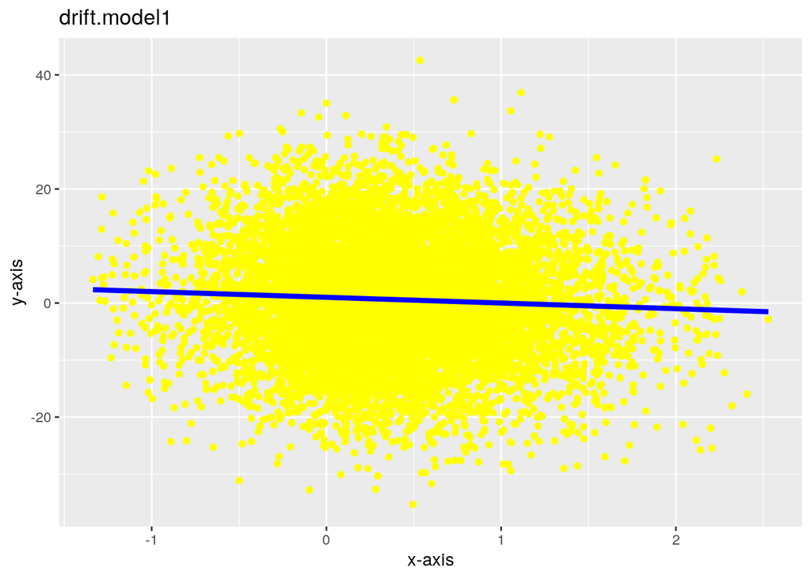

```r
#### Model 1
cloud.model1 <- cloud.fun("drift.model1",S1,Z1); cloud.model1
```

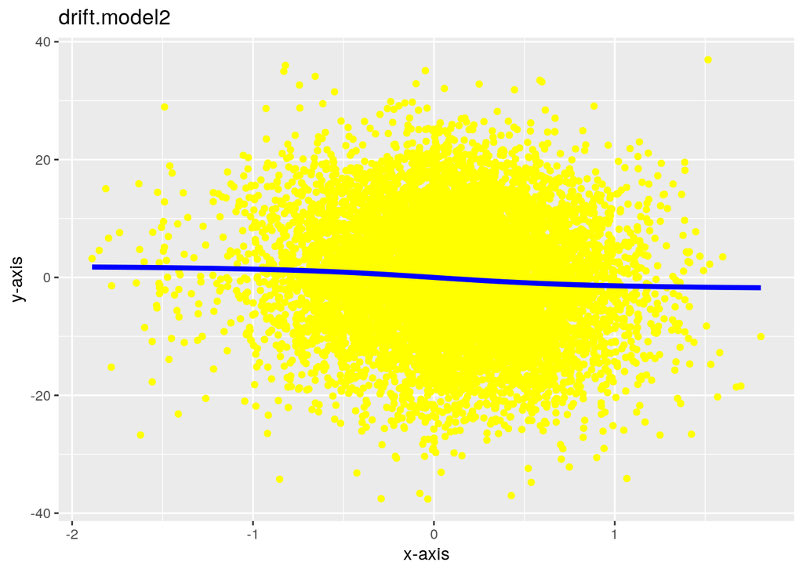

```r
#### Model 2
cloud.model2 <- cloud.fun("drift.model2",S2,Z2); cloud.model2
```

The initial space is approximated by a finite-dimensional subspace $\mathcal{S}_{K,M}$ generated by the spline basis:
$$\mathcal{S}_{K,M} = \mathrm{Span}\left\{B_{\ell}, ~~ \ell = -M,\ldots, K-1\right\}.$$

```r
#### Implementation of the spline basis

## The function lab.fun() return vector of 0 and 1, where 0 is returned for values outside of the interval [lower,upper]

lab.fun <- function(x,lower,upper) sapply(x,function(a) (a >= lower)*(a <= upper))


## Function bound.fun() replace each component of x that is not in the interval [lower,upper] by lower

bound.fun <- function(x,lower,upper) sapply(x,function(a) (a-lower)*(a >= lower)*(a <= upper)+lower)


## The function bspline() evaluates the B-spline basis' functions

bspline <- function(x,lower,upper,K,M){
  y <- bound.fun(x,lower,upper)            ## Vector y only contains values of x in between lower and upper
  id <- diag(lab.fun(x,lower,upper))       ## Diagonal matrix
  dm <- K+M                                ## Dimension of the subspace
  bs_basis <- create.bspline.basis(rangeval=c(lower,upper),nbasis=dm) ## Spline basis
  v.basis <- eval.basis(y, basisobj = bs_basis)                       ## Evaluation of the basis
  if(length(id)!=0) result <- id%*%v.basis                            ## Exclusion of values of x not in between lower and upper
  if(length(id)==0) result <- 0*v.basis

  return(result)
}
```

```r
#### Example
M = 3; K = 1; lower = -1; upper = 1
x  = seq(-1,1,0.2)
bspline(x,lower,upper,K,M)
```

```
##       bspl4.1 bspl4.2 bspl4.3 bspl4.4
##  [1,]   1.000   0.000   0.000   0.000
##  [2,]   0.729   0.243   0.027   0.001
##  [3,]   0.512   0.384   0.096   0.008
##  [4,]   0.343   0.441   0.189   0.027
##  [5,]   0.216   0.432   0.288   0.064
##  [6,]   0.125   0.375   0.375   0.125
##  [7,]   0.064   0.288   0.432   0.216
##  [8,]   0.027   0.189   0.441   0.343
##  [9,]   0.008   0.096   0.384   0.512
## [10,]   0.001   0.027   0.243   0.729
## [11,]   0.000   0.000   0.000   1.000
```

The drift function $b$ is estimated on the interval $[-\log(N),\log(N)]$ on which the spline basis is built and that tends to $\mathbb{R}$ as $N\rightarrow \infty$. Theoreticaly, the Mean Integrated Square Error (MISE) of the estimator of $b$ is upper-bounded as follows:
$$\mathbb{E}\left[\left\|\widehat{b} - b\right\|^{2}_{n}\right] \leq \mathbb{E}\left[\left\|(\widehat{b} - b\right\|^{2}_{n})\mathbf{1}_{[-\log(N),\log(N)]}\right] + C\underset{t\in[0,1]}{\sup}{\mathbb{P}\left(|X_t|>\log(N)\right)}$$

and the second term on the $\textit{rhs}$ is a negligible term with respect to the estimation error.

We add a $\ell^2$-constraint on the coordinate vectors and deduce the following constrained space
$$\mathcal{S}_{K,L,M} = \left\{h = \sum_{\ell=-M}^{K-1}{a_{\ell}B_{\ell}},~~ \sum_{\ell=-M}^{K-1}{a^{2}_{\ell}} \leq (K+M)L, ~~ L\in\mathbb{R}_{+*}\right\}.$$
From the sample $D_N$ and for each dimension $K+M$, the projection estimator $\widehat{b}_K$ of $b$ is given by
$$\widehat{b}_{K} \in \underset{h\in\mathcal{S}_{K,L,M}}{\arg\min}{\gamma_{n,N}(h)}$$
where $\gamma_{n,N}$ is the least squares contrast function defined by
$$\gamma_{n,N}(h) = \frac{1}{Nn}\sum_{j=1}^{N}{\sum_{k=0}^{n-1}{\left(Z^{j}_{k\Delta} - b(X^{j}_{\Delta})\right)^2}}.$$
We deduce that $\widehat{b}_K = \sum_{\ell=-M}^{K-1}{\widehat{a}_{\ell}B_{\ell}}$ where $\widehat{\mathbf{a}} = (\widehat{a}_{-M},\ldots,\widehat{a}_{K-1})$ is defined by
$$\widehat{\mathbf{a}} = (\mathbf{B}^{\prime}\mathbf{B})^{-1}\mathbf{B}^{\prime}\mathbf{Z} ~~~~ \mathrm{if} ~~ \det(\mathbf{B}^{\prime}\mathbf{B}) \neq 0 ~~~ \mathrm{and} ~~~ \|\mathbf{a}\|^{2}_{2} \leq (K+M)L,$$
or
$$\widehat{\mathbf{a}}_{\widehat{\lambda}} = (\mathbf{B}^{\prime}\mathbf{B} + \widehat{\lambda}I_{K+M})^{-1}\mathbf{B}^{\prime}\mathbf{Z} ~~~~ \mathrm{if} ~~ \det(\mathbf{B}^{\prime}\mathbf{B}) = 0 ~~~ \mathrm{and} ~~~ \|\mathbf{a}\|^{2}_{2} = (K+M)L, ~~~ \mathrm{where} ~~~ \widehat{\mathbf{a}}_{\lambda} = (\mathbf{B}^{\prime}\mathbf{B} + \lambda I_{K+M})^{-1}\mathbf{B}^{\prime}\mathbf{Z},$$

and $\mathbf{B}^{\prime}$ is the transpose of the empirical Gram matrix $\mathbf{B}$ given by
$$\mathbf{B} = \left(\left(B_{\ell}(X^{j}_{0}), \ldots, B_{\ell}(X^{j}_{(n-1)\Delta})\right)^{\prime}\right)_{\underset{-M\leq \ell \leq K-1}{1\leq j\leq N}} \in \mathbb{R}^{Nn\times(K+M)}$$

```r
#### Implementation of the empirical Gram matrix B
B.fun <- function(Mx,lower,upper,K,M){
  N = ncol(Mx)                                             # size of the sample
  n = nrow(Mx)                                             # size of each path
  df.X <- as.data.frame(Mx[2:(n-1),])
  l.X <- as.list(df.X)
  B. <- lapply(l.X,function(x) bspline(x,lower,upper,K,M)) # Computation of the Gram matrix
  B.. <- lapply(B.,function(x) as.data.frame(x))           # Conversion of lists contained in B. into dataframes
  B <- rbindlist(B..)                                      # The Gram matrix

  return(as.matrix(B))
}
```

The argument $\texttt{Mx}$ is a matrix whose columns are diffusion paths of the sample $D_N$. We implement the coordinate vector of the projection estimator as follows:

```r
#### The function ridge returns the difference between the square of the l2 norm of the coordinate vector and its upper-bound
ridge <- function(lambda,matrix.B,vector.Z,K,M,L){
  upper_bd = (K+M)*L;
  u = ginv(t(matrix.B)%*%matrix.B + lambda*diag(K+M))%*%t(matrix.B)%*%vector.Z
  result = sum(u^2) - upper_bd

  return(result)
}

#### The function optim.fun compute the coordinate vector of the projection estimator
optim.fun <- function(matrix.B,vector.Z,K,M,L){
  upper_bound <- sqrt(L*(K+M))
  estimator <- ginv(t(matrix.B)%*%matrix.B)%*%t(matrix.B)%*%vector.Z;
  norm_estimator <- sqrt(sum(estimator^2))
  Px = t(matrix.B) %*% matrix.B
  if(det(Px) != 0 & norm_estimator <= upper_bound){
    result <- estimator
  }else{
    ridge.bis <- function(x) ridge(x,matrix.B,vector.Z,K,M,L)
    root = multiroot(ridge.bis, c(0.01));
    lambda <- root$root
    result <- ginv(t(matrix.B)%*%matrix.B+lambda*diag(K+M))%*%t(matrix.B)%*%vector.Z;
  }

  return(result)
}
```

We truncate the estimator $\widehat{b}_K$ and we obtain
$$\widehat{b}^{L}_{K}(x) = \widehat{b}_{K}(x)\mathbf{1}_{|\widehat{b}_K(x)|\leq\sqrt{L}} + \mathrm{sign}(\widehat{b}_K(x))\sqrt{L}\mathbf{1}_{|\widehat{b}_K(x)|>\sqrt{L}}.$$

```r
## Sign of a real number
sign<-function(x) -1*(x<=0)+1*(x>0)

## Truncation of x
estim.bound<-function(x,L.N) sapply(x,function(a) a*(abs(a)<=sqrt(L.N))+sign(a)*sqrt(L.N)*(abs(a)>sqrt(L.N)))

## Estimator of the drift function
drift.bs <- function(x, a.ch, lower, upper, K, M, L){
  lab <- lab.fun(x, lower, upper)
  id.mat <- diag(lab)
  bsMat = bspline(x, lower, upper, K, M)                # Use of the spline functions
  if(length(id.mat)!=0){
    bs.Mat <- id.mat%*%bsMat;
    b.values <- bs.Mat%*%a.ch                           # Coordinate vector of the estimator
}
  if(length(id.mat)==0) b.values <- 0*a.ch;
  b.values<-estim.bound(b.values,L)                     # Truncation of the coordinate vector

  return(as.vector(b.values))
}
```

The function $\texttt{drift.bs}$ implements the truncated estimator $\widehat{b}^{L}_{K}$ of the drift function $b$, and the function $\texttt{squareerror_drf}$ computes its MISE. It remains to select an optimal dimension of the approximation space. Then, we select the dimension $\widehat{K}+M$ such that
$$\widehat{K} = \underset{K\in\mathcal{K}}{\arg\min}{\left\{\gamma_{n,N}(\widehat{b}_{K}) + \mathrm{pen}(K)\right\}} ~~~~ (2)$$
where $\mathcal{K} = \left\{2^q, ~~ q = 0, \ldots, q_{\max}\right\}$ with $2^{q_{\max}} \leq \sqrt{N}/\log(N)$, and $\mathrm{pen}(K)= \kappa(K+M)\log(N)/N$. The numerical parameter $\kappa$ is calibrated to $\kappa = 0.1$ in $\texttt{Denis,Dion,Martinez (2020)}$.

```r
#### Selection of dimension - computation of the average loss error of estimation - drift function

## Average loss error of estimation

squareerror_drf<-function(drift.name,matrix.X,a.ch,lower,upper,K,M,L){
  coeff=coef.fun(drift.name);
  result<-apply(matrix.X,2,function(x) mean(((drift.bs(x,a.ch,lower,upper,K,M,L)-coeff(x))**2)*(x>=lower)*(x<=upper)));

  return(mean(result))
}


## The penalized contrast function

gamma_pen<-function(x,c,K,M,Z,B,n,N) (1/(n*N))*sum((Z-B%*%x)**2)+c*(log(N))*(K+M)/N;


## Synthesis - Average loss error of the adaptive estimator of the drift function

kerror_drift<-function(fun.name,c,X,D,set.K,M,lower,upper,delta,L.N){
  n<-nrow(X)-1; N<-ncol(X); N.<-ncol(D); Z<-Z.fun(X,delta)
  B.ls<-lapply(1:length(set.K),function(x) B.fun(X,lower,upper,set.K[x],M))
  a.ls<-lapply(1:length(set.K),function(x) optim.fun(B.ls[[x]],Z,set.K[x],M,L.N))
  gpen.vec<-sapply(1:length(set.K),function(x) gamma_pen(a.ls[[x]],c,set.K[x],M,Z,B.ls[[x]],n,N))
  i.min<-which.min(gpen.vec)
  K.ch<-set.K[i.min]
  a.ch<-a.ls[[i.min]]

  error<-squareerror_drf(fun.name,D,a.ch,lower,upper,K.ch,M,L.N)
  result=c(K.ch,error)

  return(result)
}


## The function drift.error() below returns the estimate error knowing K and c

drift.error<-function(fun.name,X,D,K,M,lower,upper,delta,L.N){
  Z<-Z.fun(X,delta); B<-B.fun(X,lower,upper,K,M);
  a.ch<-optim.fun(B,Z,K,M,L.N)
  result<-squareerror_drf(fun.name,D,a.ch,lower,upper,K,M,L.N)

  return(result)
}
```

The function $\texttt{kerror_drift}$ takes as arguments the name $\texttt{fun.name}$ of the function to be estimated, a training sample $\texttt{X}$ and a test sample $\texttt{D}$ for the estimation of $b$ and the computation of the MISE of the estimator, the set $\texttt{set.K}$ of values of $K\in\mathcal{K}$, the integer $M \geq 1$ that completes the dimension of the subspace, the bounds $\texttt{lower, upper}$ of the estimation interval, the time-step $\texttt{delta}$ and the numerical constant $L>0$ that appears in the definition of the constrained subspace. The function returns an optimal dimension of the subspace obtained by minimizing the penalized contrast given in Equation $(2)$, and the MISE of the adaptive estimator $\widehat{b}_{\widehat{K}}$.

We also consider the oracle estimator $\widehat{b}^{L}_{K^{*}}$ of the drift function $b$ where $K^{*}$ satisfies
$$K^{*} \in \underset{K\in\mathcal{K}}{\arg\min}{~\mathbb{E}\left[\left\|\widehat{b}_{K} - b\right\|^{2}\right]}.$$

We can then compare the respective performances of estimators $\widehat{b}^{L}_{\widehat{K}}$ and $\widehat{b}^{L}_{K^{*}}$ to assess the efficiency of the adaptive estimator.

```r
## Average loss error of the oracle estimator of the drift function
kerror.drift<-function(fun.name,X,D,set.K,M,lower,upper,delta,L.N){
  n<-nrow(X)-1; N<-ncol(X); Z<-Z.fun(X,delta);
  B.ls<-lapply(set.K,function(x) B.fun(X,lower,upper,x,M))
  a.ls<-lapply(1:length(set.K),function(x) optim.fun(B.ls[[x]],Z,set.K[x],M,L.N))
  er.vec<-sapply(1:length(set.K),function(x) squareerror_drf(fun.name,D,a.ls[[x]],lower,upper,set.K[x],M,L.N))
  i.min<-which.min(er.vec)
  K.ch<-set.K[i.min]
  a.ch<-a.ls[[i.min]]

  error<-squareerror_drf(fun.name,D,a.ch,lower,upper,K.ch,M,L.N)
  result<-c(K.ch,error)

  return(result)
}
```

The function $\texttt{kerror.drift}$ takes exactly the same arguments as the function $\texttt{kerror_drift}$ corresponding to the adaptive estimator.

$\textbf{Application}$

We propose the estimation of the drift function of each diffusion model using samples $D_N$ where $N \in \{100,1000\}$ and the length $n$ of paths takes values in $\{100,500\}$. We evaluate the MISE of the truncated estimator $\widehat{b}^{L}_{\widehat{K}}$ over $5$ repetitions.

```r
#### Additional hyperparameters

N=100;          # Size of the training sample
N.=100;         # Size of the test sample
n=100           # Length of diffusion paths
delta=1/n       # Time-step
L = log(N)          # Numerical parameter appearing in the definition of the constrained approximation space
set.K = which(2^(0:5)<=sqrt(N)/log(N))     # Set of values of the integer K (dimension of the spline space)
set.K;
```

```
## [1] 1 2
```

```r
#### Efficiency of the adaptive estimator of the diffusion coefficient for Model 1 and N=100, n=100

N=100;          # Size of the training sample
N.=100;         # Size of the test sample
n=100           # Length of diffusion paths
delta=1/n       # Time-step
L = log(N)          # Numerical parameter appearing in the definition of the constrained approximation space
set.K = which(2^(0:5)<=sqrt(N)/log(N))     # Set of values of the integer K (dimension of the spline space)

drift <- coef.fun("drift.model1")                     # Drift function
sig <- coef.fun("sig.model1")                         # Diffusion coefficient
sig.x<-coef.fun("sigx.model1")                        # Derivative of the diffusion coefficient

model.name<-"drift"              # Model
lower = -log(N); upper = log(N)

n.rep<-5                         # Number of repetitions

drf_error1<-rep(NA, n.rep)        # Vector of values of the Mean Square Error of the truncated estimator
drf.error1<-rep(NA, n.rep)        # Vector of values of the Mean Square Error of the oracle estimator

for(i in 1:n.rep){
  X = model.sim(x0,n,N,model.name);
  D = model.sim(x0,n,N.,model.name);
  K=kerror_drift("drift",0.1,X,D,set.K,M,lower,upper,delta,L)[1];
  drf_error1[i] <- drift.error("drift",X,D,K,M,lower,upper,delta,L)
  drf.error1[i] <- kerror.drift("drift",X,D,set.K,M,lower,upper,delta,L)[2]
}


#### Efficiency of the adaptive estimator of the diffusion coefficient for Model 1 and N=1000, 100

N=1000;          # Size of the training sample
N.=100;         # Size of the test sample
n=100           # Length of diffusion paths
delta=1/n       # Time-step
L = log(N)          # Numerical parameter appearing in the definition of the constrained approximation space
set.K = which(2^(0:5)<=sqrt(N)/log(N))     # Set of values of the integer K (dimension of the spline space)

drift <- coef.fun("drift.model1")                     # Drift function
sig <- coef.fun("sig.model1")                         # Diffusion coefficient
sig.x<-coef.fun("sigx.model1")                        # Derivative of the diffusion coefficient

model.name<-"drift"              # Model
lower = -log(N); upper = log(N)

n.rep<-5                         # Number of repetitions

drf_error2<-rep(NA, n.rep)        # Vector of values of the Mean Square Error of the truncated estimator
drf.error2<-rep(NA, n.rep)        # Vector of values of the Mean Square Error of the oracle estimator

for(i in 1:n.rep){
  X = model.sim(x0,n,N,model.name);
  D = model.sim(x0,n,N.,model.name);
  K=kerror_drift("drift",0.1,X,D,set.K,M,lower,upper,delta,L)[1];
  drf_error2[i] <- drift.error("drift",X,D,K,M,lower,upper,delta,L)
  drf.error2[i] <- kerror.drift("drift",X,D,set.K,M,lower,upper,delta,L)[2]
}


#### Efficiency of the adaptive estimator of the diffusion coefficient for Model 1 and N=1000, 500

N=1000;          # Size of the training sample
N.=100;         # Size of the test sample
n=500           # Length of diffusion paths
delta=1/n       # Time-step
L = log(N)          # Numerical parameter appearing in the definition of the constrained approximation space
set.K = which(2^(0:5)<=sqrt(N)/log(N))     # Set of values of the integer K (dimension of the spline space)

drift <- coef.fun("drift.model1")                     # Drift function
sig <- coef.fun("sig.model1")                         # Diffusion coefficient
sig.x<-coef.fun("sigx.model1")                        # Derivative of the diffusion coefficient

model.name<-"drift"              # Model
lower = -log(N); upper = log(N)

n.rep<-5                         # Number of repetitions

drf_error3<-rep(NA, n.rep)        # Vector of values of the Mean Square Error of the truncated estimator
drf.error3<-rep(NA, n.rep)        # Vector of values of the Mean Square Error of the oracle estimator

for(i in 1:n.rep){
  X = model.sim(x0,n,N,model.name);
  D = model.sim(x0,n,N.,model.name);
  K=kerror_drift("drift",0.1,X,D,set.K,M,lower,upper,delta,L)[1];
  drf_error3[i] <- drift.error("drift",X,D,K,M,lower,upper,delta,L)
  drf.error3[i] <- kerror.drift("drift",X,D,set.K,M,lower,upper,delta,L)[2]
}
```

```r
######### Results

Estimators <- c(rep("Adaptive_estimator",3),rep("Oracle_estimator",3))
Size <- rep(c("N=100, n=100","N=1000, n=100","N=1000, n=500"),2)
MISE_mean <- c(mean(drf_error1),mean(drf_error2),mean(drf_error3),mean(drf.error1),mean(drf.error2),mean(drf.error3))
MISE_sd <- c(sd(drf_error1),sd(drf_error2),sd(drf_error3),sd(drf.error1),sd(drf.error2),sd(drf.error3))
data.frame(Estimators,Size,round(MISE_mean,3),round(MISE_sd,3))
```

```
##           Estimators          Size round.MISE_mean..3. round.MISE_sd..3.
## 1 Adaptive_estimator  N=100, n=100               0.019             0.025
## 2 Adaptive_estimator N=1000, n=100               0.003             0.002
## 3 Adaptive_estimator N=1000, n=500               0.002             0.001
## 4   Oracle_estimator  N=100, n=100               0.019             0.025
## 5   Oracle_estimator N=1000, n=100               0.003             0.002
## 6   Oracle_estimator N=1000, n=500               0.002             0.001
```

We can observe that the estimators are consistent. Moreover, we remark from the numerical result that the length $n$ of paths does not have any significant impact on the performance of the estimators. We only consider $5$ repetitions to compute the MISE of the estimators. To obtain more accurate results, it is recommended to repeat $100$ or more times.

For Model $2$, we evaluate the efficiency of $\widehat{\sigma}^{2}_{\widehat{K},L}$ and $\widehat{\sigma}^{2}_{K^{*},L}$ on samples of size $N\in\{100,1000\}$ with $n=100$.

```r
#### Efficiency of the adaptive estimator of the diffusion coefficient for Model 2 and N=100, n=100

N=100;          # Size of the training sample
N.=100;         # Size of the test sample
n=100           # Length of diffusion paths
delta=1/n       # Time-step
L = log(N)          # Numerical parameter appearing in the definition of the constrained approximation space
set.K = which(2^(0:5)<=sqrt(N)/log(N))     # Set of values of the integer K (dimension of the spline space)

drift <- coef.fun("drift.model2")                     # Drift function
sig <- coef.fun("sig.model1")                         # Diffusion coefficient
sig.x<-coef.fun("sigx.model1")                        # Derivative of the diffusion coefficient

model.name<-"drift"              # Model
lower = -log(N); upper = log(N)

n.rep<-5                         # Number of repetitions

drf_error.1<-rep(NA, n.rep)        # Vector of values of the Mean Square Error of the truncated estimator
drf.error.1<-rep(NA, n.rep)        # Vector of values of the Mean Square Error of the oracle estimator

for(i in 1:n.rep){
  X = model.sim(x0,n,N,model.name);
  D = model.sim(x0,n,N.,model.name);
  K=kerror_drift("drift",0.1,X,D,set.K,M,lower,upper,delta,L)[1];
  drf_error.1[i] <- drift.error("drift",X,D,K,M,lower,upper,delta,L)
  drf.error.1[i] <- kerror.drift("drift",X,D,set.K,M,lower,upper,delta,L)[2]
}


#### Efficiency of the adaptive estimator of the diffusion coefficient for Model 2 and N=1000, 100

N=1000;          # Size of the training sample
N.=100;         # Size of the test sample
n=100           # Length of diffusion paths
delta=1/n       # Time-step
L = log(N)          # Numerical parameter appearing in the definition of the constrained approximation space
set.K = which(2^(0:5)<=sqrt(N)/log(N))     # Set of values of the integer K (dimension of the spline space)

drift <- coef.fun("drift.model2")                     # Drift function
sig <- coef.fun("sig.model1")                         # Diffusion coefficient
sig.x<-coef.fun("sigx.model1")                        # Derivative of the diffusion coefficient

model.name<-"drift"              # Model
lower = -log(N); upper = log(N)

n.rep<-5                         # Number of repetitions

drf_error.2<-rep(NA, n.rep)        # Vector of values of the Mean Square Error of the truncated estimator
drf.error.2<-rep(NA, n.rep)        # Vector of values of the Mean Square Error of the oracle estimator

for(i in 1:n.rep){
  X = model.sim(x0,n,N,model.name);
  D = model.sim(x0,n,N.,model.name);
  K=kerror_drift("drift",0.1,X,D,set.K,M,lower,upper,delta,L)[1];
  drf_error.2[i] <- drift.error("drift",X,D,K,M,lower,upper,delta,L)
  drf.error.2[i] <- kerror.drift("drift",X,D,set.K,M,lower,upper,delta,L)[2]
}
```

```r
######### Results

Estimators <- c(rep("Adaptive_estimator",2),rep("Oracle_estimator",2))
Size <- rep(c("N=100, n=100","N=1000, n=100"),2)
MISE_mean <- c(mean(drf_error.1),mean(drf_error.2),mean(drf.error.1),mean(drf.error.2))
MISE_sd <- c(sd(drf_error.1),sd(drf_error.2),sd(drf.error.1),sd(drf.error.2))
data.frame(Estimators,Size,round(MISE_mean,3),round(MISE_sd,3))
```

```
##           Estimators          Size round.MISE_mean..3. round.MISE_sd..3.
## 1 Adaptive_estimator  N=100, n=100               0.070             0.010
## 2 Adaptive_estimator N=1000, n=100               0.054             0.004
## 3   Oracle_estimator  N=100, n=100               0.070             0.010
## 4   Oracle_estimator N=1000, n=100               0.054             0.004
```